# Laboratory practice 2_1. Classification

Solution to Preprocessing the GLOW Dataset

Author

Prof. F.San Segundo, Prof. V.Varo

### Import the Dataset

We begin by importing the base libraries

```python
import numpy as np
import matplotlib.pyplot as plt
import seaborn as sns
import pandas as pd

from mltools import classification_tools as CT
from mltools import model_tools as MT
```

```python
### Load file --------------------------------------------
df =  pd.read_csv("~/code/MLMIC2024/data/GLOW/GLOW500.txt", sep="\t")
print(df.iloc[0:5, 0:8])
print(df.columns)
```

```
   SUB_ID  SITE_ID  PHY_ID  PRIORFRAC  AGE  WEIGHT  HEIGHT       BMI
0       1        1      14          0   62    70.3     158  28.16055
1       2        4     284          0   65    87.1     160  34.02344
2       3        6     305          1   88    50.8     157  20.60936
3       4        6     309          0   82    62.1     160  24.25781
4       5        1      37          0   61    68.0     152  29.43213
Index(['SUB_ID', 'SITE_ID', 'PHY_ID', 'PRIORFRAC', 'AGE', 'WEIGHT', 'HEIGHT',
       'BMI', 'PREMENO', 'MOMFRAC', 'ARMASSIST', 'SMOKE', 'RATERISK',
       'FRACSCORE', 'FRACTURE'],
      dtype='object')
```

Immediately after the import, check the basic information for resulting dataframe:

```python
df.info()
```

```
<class 'pandas.core.frame.DataFrame'>
RangeIndex: 500 entries, 0 to 499
Data columns (total 15 columns):
 #   Column     Non-Null Count  Dtype
---  ------     --------------  -----
 0   SUB_ID     500 non-null    int64
 1   SITE_ID    500 non-null    int64
 2   PHY_ID     500 non-null    int64
 3   PRIORFRAC  500 non-null    int64
 4   AGE        500 non-null    int64
 5   WEIGHT     500 non-null    float64
 6   HEIGHT     500 non-null    int64
 7   BMI        500 non-null    float64
 8   PREMENO    500 non-null    int64
 9   MOMFRAC    500 non-null    int64
 10  ARMASSIST  500 non-null    int64
 11  SMOKE      500 non-null    int64
 12  RATERISK   500 non-null    int64
 13  FRACSCORE  500 non-null    int64
 14  FRACTURE   500 non-null    int64
dtypes: float64(2), int64(13)
memory usage: 58.7 KB
```

Note that there are no *apparent* missing values. We insist in the non *apparent* status of missing data right now, beacuse in some cases you will discover downstream in the analysis that some missing values were encoded e.g. with a numerical code (we often meet codes such as 99999999 in some business contexts) and therefore they will escape this preliminary inspection.

### Remove Unused Columns from the Dataset

*Index variables should be removed before proceeding with the analysis. In our dataset this is the clearly case for the first column `SUB_ID` which is a patien identifier (a row number). The `SITE_ID` and `PHY_ID` are also identifiers, but it is not so clear how to deal with them at this point. Let us wait until we see how many different values they take and then we will decide wheter we keep them.

We have been requested in the statement to also drop the `FRACSCORE` column, so we do it now.

```python
df.drop(columns=["SUB_ID", "FRACSCORE"], inplace=True)
```

**Note about BMI:** the BMI (body mass index) is usually defined to be
$$\dfrac{\text{weight (in kg)}}{\text{height (in meters)}^2}$$
Therefore this column of the table is not an independent measure, it has been computed from the measured variables. We can confirm it with the following computation. The result indictes that the differences between the BMI column in the table are probably due to unit conversions and rounding.

```python
np.max(np.abs((df.BMI - (df.WEIGHT / (df.HEIGHT / 100)**2))))
```

```
7.163056949366364e-06
```

We could argue that this as a reason to drop the column or we can keep it and see if it helps increase the predictive performance of the model (since the experts hace considered it worth including in the table). We keep it for now, but the discussion about BMI is continued below.

Anyway, after dropping some columns always check the result:

```python
df.head()
```

|  | SITE_ID | PHY_ID | PRIORFRAC | AGE | WEIGHT | HEIGHT | BMI | PREMENO | MOMFRAC | ARMASSIST | SMOKE | RATERISK | FRACTURE |
| --- | --- | --- | --- | --- | --- | --- | --- | --- | --- | --- | --- | --- | --- |
| 0 | 1 | 14 | 0 | 62 | 70.3 | 158 | 28.16055 | 0 | 0 | 0 | 0 | 2 | 0 |
| 1 | 4 | 284 | 0 | 65 | 87.1 | 160 | 34.02344 | 0 | 0 | 0 | 0 | 2 | 0 |
| 2 | 6 | 305 | 1 | 88 | 50.8 | 157 | 20.60936 | 0 | 1 | 1 | 0 | 1 | 0 |
| 3 | 6 | 309 | 0 | 82 | 62.1 | 160 | 24.25781 | 0 | 0 | 0 | 0 | 1 | 0 |
| 4 | 1 | 37 | 0 | 61 | 68.0 | 152 | 29.43213 | 0 | 0 | 0 | 0 | 2 | 0 |

## 2 Preproc; Step 2 : Choose proper type, names and encoding for the variables

We use `nunique` to see the number of different values for each variable

```python
df.nunique()
```

```
SITE_ID        6
PHY_ID       127
PRIORFRAC      2
AGE           36
WEIGHT       128
HEIGHT        34
BMI          409
PREMENO        2
MOMFRAC        2
ARMASSIST      2
SMOKE          2
RATERISK       3
FRACTURE       2
dtype: int64
```

The result shows that `PHY_ID` is probably best considered as an identifier with little predictive worth (a ratio of 500/127 patients per doctor is too low to be of any use). Thus it will be dropped:

```python
df.drop(columns=["PHY_ID"], inplace=True)
```

On the other hand, `SITE_ID` only takes six values, so it is probably best kept as a factor. Along with `PRIORFRAC`, `PREMENO`, `MOMFRAC`, `ARMASSIST`, `SMOKE` and `RATERISK` that should all be considered input factors. Think about the meaning of each of this variables and discuss with yourself if they appear to be legitimate factors, useful to define groups in this dataset that can help us predict the output. The remaining inputs `AGE`, `WEIGHT`, `HEIGHT`, `BMI` are best kept as numerical inputs.

We could discuss if we should consider `RATERISK` as an ordered factor, but with only three levels there is little to be gained in doing that.

Next we set the type of all categorical variables including the output:

```python
output = 'FRACTURE'
cat_inputs = ["SITE_ID", "PRIORFRAC", "PREMENO", "MOMFRAC",
              "ARMASSIST", "SMOKE", "RATERISK"]
df[cat_inputs + [output]] = df[cat_inputs + [output]].astype("category")
df.info()
```

```
<class 'pandas.core.frame.DataFrame'>
RangeIndex: 500 entries, 0 to 499
Data columns (total 12 columns):
 #   Column     Non-Null Count  Dtype
---  ------     --------------  -----
 0   SITE_ID    500 non-null    category
 1   PRIORFRAC  500 non-null    category
 2   AGE        500 non-null    int64
 3   WEIGHT     500 non-null    float64
 4   HEIGHT     500 non-null    int64
 5   BMI        500 non-null    float64
 6   PREMENO    500 non-null    category
 7   MOMFRAC    500 non-null    category
 8   ARMASSIST  500 non-null    category
 9   SMOKE      500 non-null    category
 10  RATERISK   500 non-null    category
 11  FRACTURE   500 non-null    category
dtypes: category(8), float64(2), int64(2)
memory usage: 20.7 KB
```

Similarly we identify the set of numerical inputs and create an index of all input variables.

```python
inputs = df.columns.drop(output)
num_inputs = inputs.difference(cat_inputs).tolist()
print(inputs)
```

```
Index(['SITE_ID', 'PRIORFRAC', 'AGE', 'WEIGHT', 'HEIGHT', 'BMI', 'PREMENO',
       'MOMFRAC', 'ARMASSIST', 'SMOKE', 'RATERISK'],
      dtype='object')
```

One Hot Encoding of the Categorical Inputs. We use this one hot encoding and add the resulting new columns to the DataFrame, also keeping the columns with previous versions of the categorical inputs.

```python
from sklearn.preprocessing import OneHotEncoder

ohe = OneHotEncoder(sparse_output=False)
ohe_result = ohe.fit_transform(df[cat_inputs])

ohe_inputs = [ohe.categories_[k].tolist() for k in range(len(cat_inputs))]
ohe_inputs = [cat_inputs[k] + "_" + str(a) for k in range(len(cat_inputs)) for a in ohe_inputs[k]]

ohe_df = pd.DataFrame(ohe_result, columns=ohe_inputs)
df[ohe_inputs] = ohe_df

df.info()
```

```
<class 'pandas.core.frame.DataFrame'>
RangeIndex: 500 entries, 0 to 499
Data columns (total 31 columns):
 #   Column       Non-Null Count  Dtype
---  ------       --------------  -----
 0   SITE_ID      500 non-null    category
 1   PRIORFRAC    500 non-null    category
 2   AGE          500 non-null    int64
 3   WEIGHT       500 non-null    float64
 4   HEIGHT       500 non-null    int64
 5   BMI          500 non-null    float64
 6   PREMENO      500 non-null    category
 7   MOMFRAC      500 non-null    category
 8   ARMASSIST    500 non-null    category
 9   SMOKE        500 non-null    category
```

[output cut: 23 more lines]

# 2 Preprocessing, Step 3: Check out the missing values

We saw before that there are no *apparent* missing values. Let us check that again (to see that we have not lost any value, this is important when preprocessing gets more involved, with table melting, etc.). How does this work, what is the purpose of the second sum?

```python
df.isnull().sum(axis=0).sum()
```

```
0
```

# 2 Preprocessing, Step 4: Split the dataset into Training and Test Sets

We give standard names to the input and output variables as follows:

```python
X = df.drop(columns=output)
Y = df[output]
```

And then proceed to the actual (stratified) splitting:

```python
from sklearn.model_selection import train_test_split
XTR, XTS, YTR, YTS = train_test_split(X, Y,
                                      test_size=0.2,  # percentage preserved as test data
                                      random_state=1, # seed for replication
                                      stratify = Y)   # Preserves distribution of y
```

# 2 Preproc; Step 5: Plot the numeric variables in training data and check out for outliers

Let us begin by plotting boxplots of the numeric inputs:

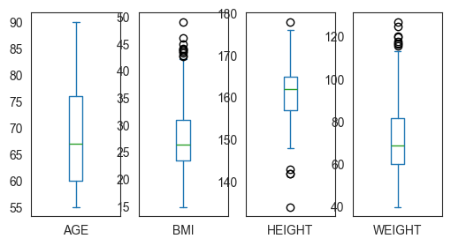

```python
XTR_numeric_boxplots = XTR[num_inputs].plot.box(subplots=True,
                                            layout=(1, len(num_inputs)),
                                            sharex=False, sharey=False, figsize=(6, 3))
```

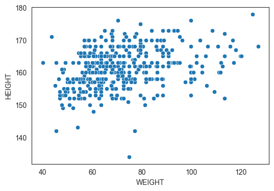

```python
fig, ax = plt.subplots(figsize=(6, 4))
sns.scatterplot(XTR, x='WEIGHT', y = 'HEIGHT', ax=ax)
```

The plot suggests that it is ok to drop the outliers in `HEIGHT`. We run the following function, described in this session’s notebook (we have commented some lines of code to suppress the plots, we do not need them now):

```python
from matplotlib.cbook import boxplot_stats

def explore_outliers(df, num_vars):
    # fig, axes = plt.subplots(nrows=len(num_vars), ncols=1, figsize=(7, 3), sharey=False, sharex=False)
    # fig.tight_layout()
    outliers_df = dict()
    for k in range(len(num_vars)):
        var = num_vars[k]
        # sns.boxplot(df, x=var , ax=axes[k])
        outliers_df[var] = boxplot_stats(df[var])[0]["fliers"]
        out_pos = np.where(df[var].isin(outliers_df[var]))[0].tolist()
        out_idx = [df[var].index.tolist()[ k ] for k in out_pos]
        outliers_df[var] = {"values": outliers_df[var],
                            "positions": out_pos,
                            "indices": out_idx}
    return outliers_df
```

and now use the result to drop the outliers in `HEIGHT`(we also drop the corresponding output values).

```python
out_XTR = explore_outliers(XTR, num_inputs)
out_XTR_indices = set([k for var in ['HEIGHT'] for k in out_XTR[var]["indices"] ])
XTR.drop(out_XTR_indices, axis=0, inplace=True)

# Also make sure to remove the corresponding output values in `YTR`.

YTR.drop(out_XTR_indices, axis=0, inplace=True) # Always keep in mind that you need to keep `YTR` updated.
```

If yow run `explore_outliers(XTR, num_inputs)` you will see that those outliers have indeed been dropped.

**REMARK:**

The analysis of outliers and the EDA below give us another opportunity to think about missing data. Check the ranges of the variables and for anything else that stands out as unexpected, because sometimes that is the only way to spot previously undetected missing values.

# 2 Preproc; Step 6: EDA and Feature selection or engineering. Pipelines.

We begin using the `describe` function to obtain numerical summaries for the variables. For numeric inputs:

```python
XTR[num_inputs].describe().transpose()
```

|  | count | mean | std | min | 25% | 50% | 75% | max |
| --- | --- | --- | --- | --- | --- | --- | --- | --- |
| AGE | 395.0 | 68.308861 | 8.937220 | 55.00000 | 60.00000 | 67.00000 | 76.000000 | 90.00000 |
| BMI | 395.0 | 27.644980 | 5.943626 | 14.87637 | 23.38577 | 26.36709 | 30.896355 | 49.08241 |
| HEIGHT | 395.0 | 161.440506 | 5.696947 | 148.00000 | 157.00000 | 162.00000 | 165.000000 | 176.00000 |
| WEIGHT | 395.0 | 72.163038 | 16.405359 | 39.90000 | 60.30000 | 68.90000 | 81.600000 | 127.00000 |

For input factors we obtain the mode and its frequency:

```python
XTR[cat_inputs].describe().transpose()
```

|  | count | unique | top | freq |
| --- | --- | --- | --- | --- |
| SITE_ID | 395 | 6 | 5 | 95 |
| PRIORFRAC | 395 | 2 | 0 | 299 |
| PREMENO | 395 | 2 | 0 | 320 |
| MOMFRAC | 395 | 2 | 0 | 346 |
| ARMASSIST | 395 | 2 | 0 | 244 |
| SMOKE | 395 | 2 | 0 | 367 |
| RATERISK | 395 | 3 | 2 | 152 |

Nothing looks surprising or unexpected in these tables, so we keep believing that the training set contains no missing data.

Next we draw a pairplot to explore the distribution and relations between those variables.

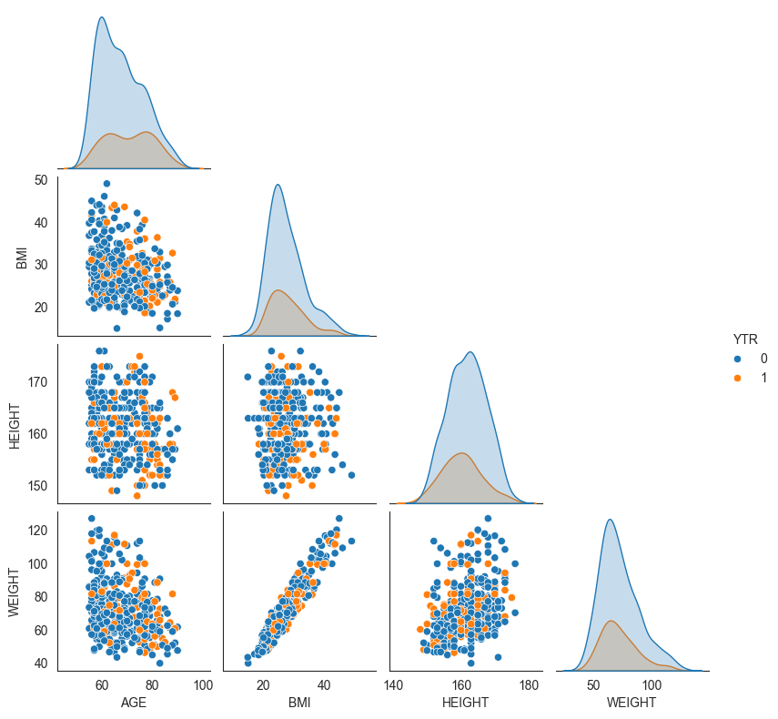

```python
sns.set_style("white")
plt_df = XTR[num_inputs].copy()
plt_df["YTR"] = YTR
sns.pairplot(plt_df, hue="YTR", corner=True, height=2)
```

The pairplot reveals a clear pattern that involves `WEIGHT` and `BMI`. This comes as no surprise, since as previously discussed `BMI` is a derived quantity and taking into account the limited range of human heights (around 1.6). In particular, keeping `BMI` in the dataset seems to be of little use for linear models. We will come back to this when analyzing correlation.

Conditioning on the output it seems that `AGE` could be a variable of interest to separate both classes. But we will deal with this when we come to modeling. The rest of the scatterplots show no particular patterns. The density plots in the diagonal suggest that there is a certain amount of (right) ske in all of them. We can explore this further plotting the unconditioned densities:

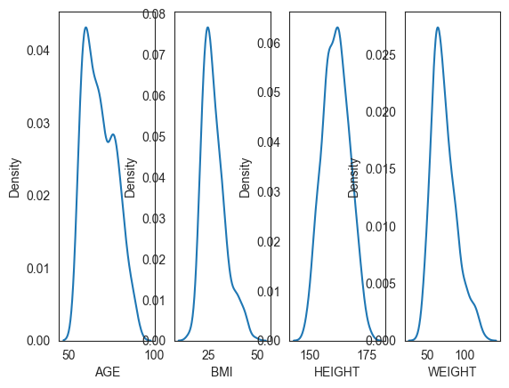

```python
fig, axes = plt.subplots(1, len(num_inputs))  # create figure and axes
for col, ax in zip(num_inputs, axes):  # boxplot for each factor inpput
    sns.kdeplot(data=XTR, x = col, ax=ax)
```

We will apply a BoxCox power transformation to bring these variables closer to the normal distribution. You can find the sklearn documentation for this transfomer here:  
https://scikit-learn.org/stable/modules/generated/sklearn.preprocessing.power_transform.html

Now we make parallel boxplots for each combination of a numerical input and a factor input.

```
Analyzing the relation between factor inputs and AGE
Analyzing the relation between factor inputs and BMI
Analyzing the relation between factor inputs and HEIGHT
Analyzing the relation between factor inputs and WEIGHT
```

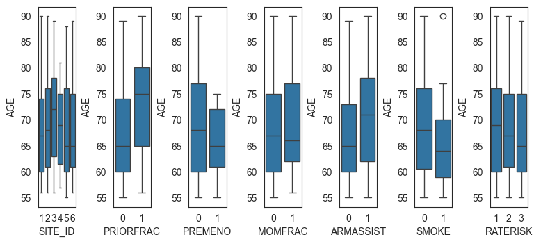

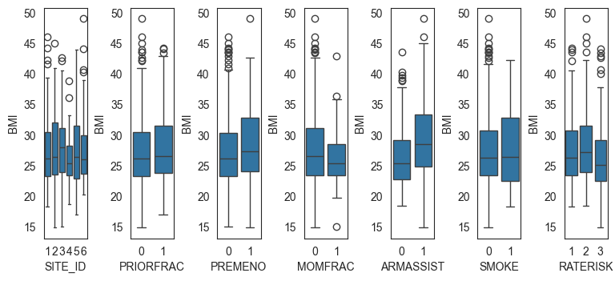

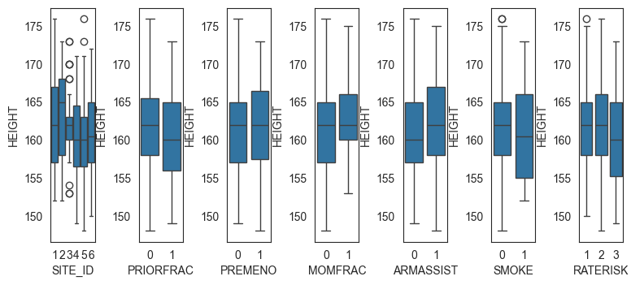

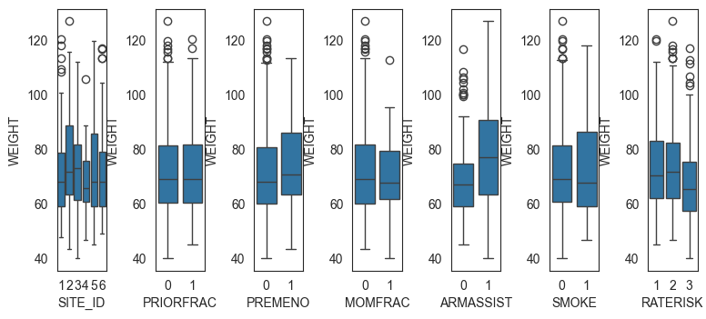

```python
for numVar in num_inputs:
    print("Analyzing the relation between factor inputs and", numVar)
    if (len(cat_inputs) > 1):
        fig, axes = plt.subplots(1, len(cat_inputs))  # create figure and axes
        for col, ax in zip(cat_inputs, axes):  # boxplot for each factor inpput
            sns.boxplot(data=XTR, x = col, y = numVar, ax=ax)
    else: # the special case of a single input factor
        fig, ax = plt.subplots()
        sns.boxplot(data=XTR, x = cat_inputs[0], y = numVar, ax=ax)
    # set subplot margins
    plt.subplots_adjust(left=0.9, bottom=0.4, right=2, top=1, wspace=1, hspace=1)
    plt.figure(figsize=(1, 1))
    plt.show()
```

Looking through all these plots you will notice that there are big overlaps between the boxes in all the plots. Therefore, knowing the value of a numerical variable does not seem to provide enough information about any of the input factors.

Let us now look at the **correlation** matrix

```python
XTR[num_inputs].corr()
```

|  | AGE | BMI | HEIGHT | WEIGHT |
| --- | --- | --- | --- | --- |
| AGE | 1.000000 | -0.252758 | -0.169126 | -0.287704 |
| BMI | -0.252758 | 1.000000 | 0.021322 | 0.949343 |
| HEIGHT | -0.169126 | 0.021322 | 1.000000 | 0.327358 |
| WEIGHT | -0.287704 | 0.949343 | 0.327358 | 1.000000 |

It confirms a very strong correlation between `WEIGHT` and `BMI`. Normally we would use the rest of the correlation matrix to decide which of the two we keep. But in this case `BMI` is a derived column so we prefer to keep the directly observed data and we will drop `BMI`.

```python
XTR.drop(columns="BMI", inplace=True)
num_inputs.remove("BMI") # Keep the list of inputs updated
XTR.info()
```

```
<class 'pandas.core.frame.DataFrame'>
Int64Index: 395 entries, 184 to 454
Data columns (total 29 columns):
 #   Column       Non-Null Count  Dtype
---  ------       --------------  -----
 0   SITE_ID      395 non-null    category
 1   PRIORFRAC    395 non-null    category
 2   AGE          395 non-null    int64
 3   WEIGHT       395 non-null    float64
 4   HEIGHT       395 non-null    int64
 5   PREMENO      395 non-null    category
 6   MOMFRAC      395 non-null    category
 7   ARMASSIST    395 non-null    category
 8   SMOKE        395 non-null    category
 9   RATERISK     395 non-null    category
```

[output cut: 21 more lines]

As we end preprocessing we now drop the original categorical inputs

```python
XTR.drop(columns=cat_inputs, inplace=True)
```

# 2 Preproc; Step 7 : Check out for Class Imbalances

We look at the relative frequencies of the classes for the output variable in training, that is `YTR`.

```python
YTR.value_counts(normalize=True)
```

```
0    0.756962
1    0.243038
Name: FRACTURE, dtype: float64
```

This 76% vs 24% imbalance can be considered as moderate. We can still proceed without turning to sampling methods, but in situations like this we recommend trying at least one sampling method to see how much of an impact it has over performance. We will return to this at the end of this document.

# Preprocessing Pipeline

After all the preceding work we are ready to create a preprocessing pipeline and apply it to the data. The pipeline will apply:

- scaling and a BoxCox power transformation to the numerical variables
- and will let the factors pass through without being altered.

We begin by importing the required functions:

```python
from sklearn.pipeline import Pipeline
from sklearn.preprocessing import StandardScaler, PowerTransformer
from sklearn.compose import ColumnTransformer
```

We define the transformation for numerical variables:

```python
num_transformer = Pipeline(
    steps=[("boxcox", PowerTransformer(method='box-cox')),
           ("scaler", StandardScaler())]
)
```

Now we use `ColumnTransformer` and we we use the string `"passthrough"` to indicate that the categorical inputs are not transformed.

```python
preprocessor = ColumnTransformer(
    transformers=[
        ("num", num_transformer, num_inputs),
        ("cat", "passthrough", ohe_inputs),
    ]
)
```

We are now ready to define the pipeline named `prep`.

```python
preproc_pipe = Pipeline(steps=[('prep', preprocessor)])
preproc_pipe.set_output(transform="pandas")
```

```
Pipeline(steps=[('prep',
                 ColumnTransformer(transformers=[('num',
                                                  Pipeline(steps=[('boxcox',
                                                                   PowerTransformer(method='box-cox')),
                                                                  ('scaler',
                                                                   StandardScaler())]),
                                                  ['AGE', 'HEIGHT', 'WEIGHT']),
                                                 ('cat', 'passthrough',
                                                  ['SITE_ID_1', 'SITE_ID_2',
                                                   'SITE_ID_3', 'SITE_ID_4',
                                                   'SITE_ID_5', 'SITE_ID_6',
                                                   'PRIORFRAC_0', 'PRIORFRAC_1',
                                                   'PREMENO_0', 'PREMENO_1',
                                                   'MOMFRAC_0', 'MOMFRAC_1',
                                                   'ARMASSIST_0', 'ARMASSIST_1',
                                                   'SMOKE_0', 'SMOKE_1',
                                                   'RATERISK_1', 'RATERISK_2',
                                                   'RATERISK_3'])]))])
```

Finally we apply this pipeline to the data with the `fit_transform` method:

```python
preproc_XTR = preproc_pipe.fit_transform(XTR)
preproc_XTR.head()
```

|  | num__AGE | num__HEIGHT | num__WEIGHT | cat__SITE_ID_1 | cat__SITE_ID_2 | cat__SITE_ID_3 | cat__SITE_ID_4 | cat__SITE_ID_5 | cat__SITE_ID_6 | cat__PRIORFRAC_0 | ... | cat__PREMENO_1 | cat__MOMFRAC_0 | cat__MOMFRAC_1 | cat__ARMASSIST_0 | cat__ARMASSIST_1 | cat__SMOKE_0 | cat__SMOKE_1 | cat__RATERISK_1 | cat__RATERISK_2 | cat__RATERISK_3 |
| --- | --- | --- | --- | --- | --- | --- | --- | --- | --- | --- | --- | --- | --- | --- | --- | --- | --- | --- | --- | --- | --- |
| 184 | -1.097607 | 0.978387 | 0.942011 | 0.0 | 1.0 | 0.0 | 0.0 | 0.0 | 0.0 | 1.0 | ... | 0.0 | 1.0 | 0.0 | 1.0 | 0.0 | 1.0 | 0.0 | 0.0 | 1.0 | 0.0 |
| 149 | -1.097607 | -0.773830 | -0.365497 | 1.0 | 0.0 | 0.0 | 0.0 | 0.0 | 0.0 | 1.0 | ... | 0.0 | 1.0 | 0.0 | 0.0 | 1.0 | 1.0 | 0.0 | 1.0 | 0.0 | 0.0 |
| 182 | -0.798863 | -0.593650 | -0.365497 | 0.0 | 0.0 | 0.0 | 0.0 | 0.0 | 1.0 | 1.0 | ... | 1.0 | 1.0 | 0.0 | 1.0 | 0.0 | 1.0 | 0.0 | 1.0 | 0.0 | 0.0 |
| 464 | -1.418504 | -0.593650 | 0.828926 | 0.0 | 1.0 | 0.0 | 0.0 | 0.0 | 0.0 | 1.0 | ... | 1.0 | 0.0 | 1.0 | 1.0 | 0.0 | 1.0 | 0.0 | 0.0 | 1.0 | 0.0 |
| 110 | 0.825443 | 0.978387 | -0.106228 | 1.0 | 0.0 | 0.0 | 0.0 | 0.0 | 0.0 | 1.0 | ... | 1.0 | 1.0 | 0.0 | 1.0 | 0.0 | 1.0 | 0.0 | 1.0 | 0.0 | 0.0 |

5 rows × 22 columns

Note the names of the variables in the transformed data set.

Let us check if the transformed numerical variables seem closer to being normally distributed. We plot their densities:

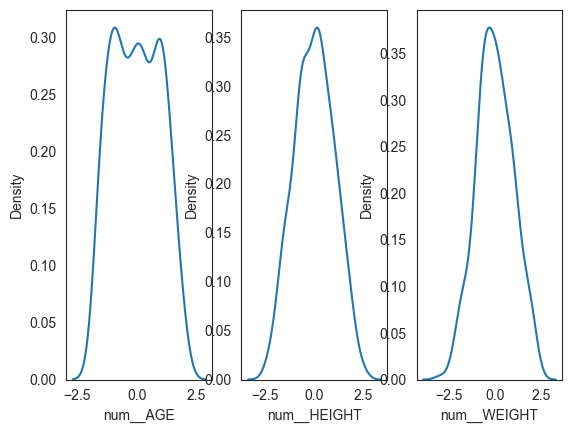

```python
fig, axes = plt.subplots(1, 3)  # create figure and axes
for col, ax in zip(preproc_XTR.iloc[:, 0:3], axes):  # boxplot for each factor inpput
    sns.kdeplot(data=preproc_XTR.iloc[:, 0:3], x = col, ax=ax)
```

Do not worry too much about the *noise* introduced by the transformation (which is clearly visible in the `num_AGE` density curve). The important thing here is that the symmetry of the distributions has clearly increased and their scales are similar.

Let us also check that the numeric inputs have been really standardized. Check the `mean` and `std` rows in the putput of describe,

```python
preproc_XTR.iloc[:, 0:3].describe()
```

|  | num__AGE | num__HEIGHT | num__WEIGHT |
| --- | --- | --- | --- |
| count | 3.950000e+02 | 3.950000e+02 | 3.950000e+02 |
| mean | -3.372829e-17 | -1.798842e-17 | 2.360981e-17 |
| std | 1.001268e+00 | 1.001268e+00 | 1.001268e+00 |
| min | -1.764061e+00 | -2.449204e+00 | -2.994788e+00 |
| 25% | -9.456097e-01 | -7.738303e-01 | -6.890385e-01 |
| 50% | -1.504923e-02 | 1.158252e-01 | -4.465291e-02 |
| 75% | 9.174160e-01 | 6.365077e-01 | 7.110224e-01 |
| max | 1.980091e+00 | 2.467740e+00 | 2.398689e+00 |

### Applying the Preprocessing Pipeline to the Test Set

This is straightforward.

```python
preproc_XTS = preproc_pipe.fit_transform(XTS)
preproc_XTS.head()
```

|  | num__AGE | num__HEIGHT | num__WEIGHT | cat__SITE_ID_1 | cat__SITE_ID_2 | cat__SITE_ID_3 | cat__SITE_ID_4 | cat__SITE_ID_5 | cat__SITE_ID_6 | cat__PRIORFRAC_0 | ... | cat__PREMENO_1 | cat__MOMFRAC_0 | cat__MOMFRAC_1 | cat__ARMASSIST_0 | cat__ARMASSIST_1 | cat__SMOKE_0 | cat__SMOKE_1 | cat__RATERISK_1 | cat__RATERISK_2 | cat__RATERISK_3 |
| --- | --- | --- | --- | --- | --- | --- | --- | --- | --- | --- | --- | --- | --- | --- | --- | --- | --- | --- | --- | --- | --- |
| 297 | -0.795692 | 0.459560 | -0.795238 | 1.0 | 0.0 | 0.0 | 0.0 | 0.0 | 0.0 | 1.0 | ... | 0.0 | 1.0 | 0.0 | 1.0 | 0.0 | 1.0 | 0.0 | 1.0 | 0.0 | 0.0 |
| 407 | 1.785208 | -0.133108 | -0.605639 | 0.0 | 0.0 | 0.0 | 0.0 | 1.0 | 0.0 | 0.0 | ... | 0.0 | 1.0 | 0.0 | 0.0 | 1.0 | 1.0 | 0.0 | 1.0 | 0.0 | 0.0 |
| 133 | 0.786101 | 0.594333 | 1.467583 | 1.0 | 0.0 | 0.0 | 0.0 | 0.0 | 0.0 | 0.0 | ... | 0.0 | 1.0 | 0.0 | 0.0 | 1.0 | 1.0 | 0.0 | 0.0 | 0.0 | 1.0 |
| 427 | 0.786101 | 0.023791 | -1.754066 | 0.0 | 0.0 | 0.0 | 0.0 | 0.0 | 1.0 | 0.0 | ... | 0.0 | 1.0 | 0.0 | 0.0 | 1.0 | 1.0 | 0.0 | 0.0 | 1.0 | 0.0 |
| 438 | -0.149840 | -0.133108 | 0.425384 | 0.0 | 1.0 | 0.0 | 0.0 | 0.0 | 0.0 | 1.0 | ... | 0.0 | 0.0 | 1.0 | 1.0 | 0.0 | 1.0 | 0.0 | 0.0 | 1.0 | 0.0 |

5 rows × 22 columns

# Optional Exercise. Dealing with Imbalance.

Read this example of how to deal with imbalance using the `SMOTE` sampling methd:

https://machinelearningmastery.com/smote-oversampling-for-imbalanced-classification/

Then install the [Imbalanced-learn](https://imbalanced-learn.org/stable/) library and use it to add the `SMOTE` subsampling method to our preprocessing pipeline.